# SPEW: A brief tour

Department of Statistics, Carnegie Mellon University

# Introduction

Welcome to SPEW (Synthetic Population and Ecosystems of the World). This guide is for use in for basic usage of the `R` package spew. This vignette will walk through the set-up of the fictitious human ecosystem of Tartanville. We show how to quickly spew a synthetic ecosystem; sample agents using different methods for location assignments, sample agents using different methods for population characteristic assignments, discuss the essential input data for SPEW, expand upon the supplementary data format required for SPEW, and briefly describe some of the more advanced functions of SPEW.

SPEW uses random sampling to sample both locations of residence for the synthetic individuals and individual records from the microdata. SPEW is modular in that it can use different methods of sampling to emphasize different aspects of the synthetic ecosystem. A few methods are demonstrated here. The methods in **bold** are the default options.

# A true quickstart

## Downloading SPEW

Open up an `R` session and run the following commands.

**Note:** the dependency `maptools` requires the `gpclib` permit. The easiest way to get this is to download the `rgeos` package.

```r
library(devtools)
if(!require(rgeos)) install.packages("rgeos")
install_github("leerichardson/spew")
```

## Tartanville: SPEW basics

```r
## libraries
library(ggplot2)
library(maptools)
library(plyr)
library(spew)

## Generating Tartanville
data(tartanville)
tartanville_syneco <- spewr(tartanville$pop_table, tartanville$shapefile,
                            tartanville$pums_h, tartanville$pums_p)
```

```
## [1] "Region 1 out of 9"
## [1] "Region 2 out of 9"
## [1] "Place has 0 Households!"
## [1] "Region 3 out of 9"
## [1] "Region 4 out of 9"
## [1] "Region 5 out of 9"
## [1] "Region 6 out of 9"
## [1] "Region 7 out of 9"
## [1] "Region 8 out of 9"
## [1] "Region 9 out of 9"
## [1] "Location runs in: 0.61"
```

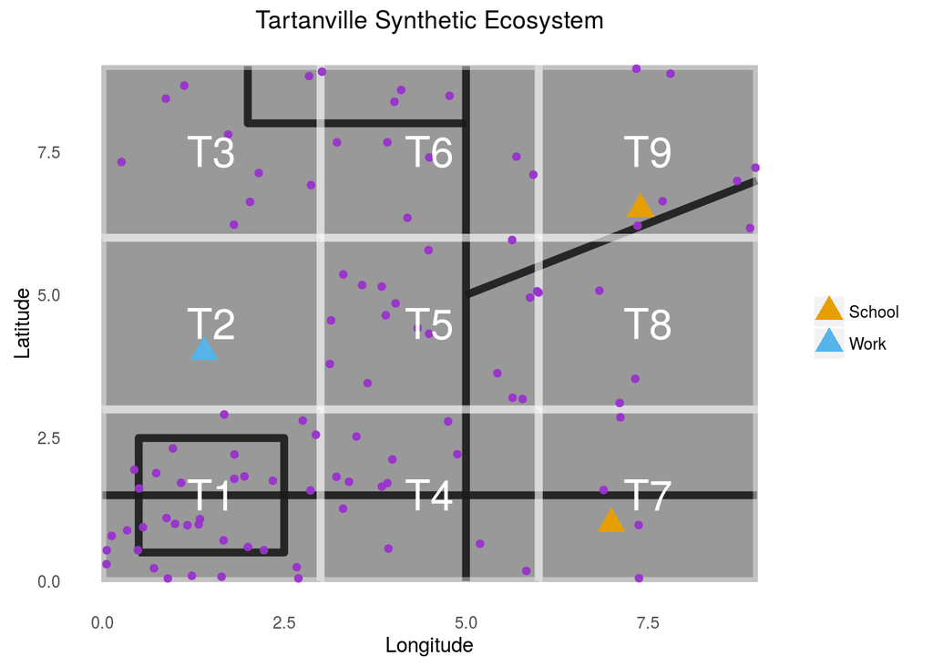

```r
plot_syneco(tartanville, tartanville_syneco,
            region_name = "Tartanville", pretty = TRUE)
```

```r
summarize_syneco(tartanville_syneco,
                 vars_df = data.frame(var_name = c("NP", "HHINC", "AGEP", "SEX"),
                                      pop_type = c("hh", "hh", "p", "p"),
                                      var_type = c("cont", "cont", "cont", "cat"),
                                      stringsAsFactors = FALSE), verbose = TRUE)
```

```
## Variable: NP
##  Summary: place_id Min. 1st Qu. Median  Mean 3rd Qu. Max.
##        T1    2     2.0      4 4.062       6    6
##        T3    2     4.0      4 4.000       4    6
##        T4    2     3.5      4 3.833       4    6
##        T5    2     2.0      4 3.333       4    6
##        T6    2     4.0      4 4.000       4    6
##        T7    2     2.0      4 3.600       4    6
##        T8    2     3.0      4 4.000       5    6
##        T9    2     3.0      4 4.000       5    6
## Variable: HHINC
##  Summary: place_id Min. 1st Qu. Median  Mean 3rd Qu. Max.
##        T1   20    42.0     42 55.06      64  108
##        T3   20    42.0     42 51.78      42  108
##        T4   20    36.5     42 58.50     108  108
##        T5   20    42.0     64 66.44     108  108
##        T6   20    42.0     42 66.20     108  108
##        T7   20    42.0     42 55.20      64  108
##        T8   42    42.0     42 49.33      53   64
##        T9   20    31.0     42 54.57      75  108
## Variable: AGEP
##  Summary: place_id Min. 1st Qu. Median  Mean 3rd Qu. Max.
##        T1    3    12.0   19.0 25.14    40.0   58
##        T3    3    12.0   19.0 22.06    34.0   48
##        T4    3    14.0   19.0 21.98    34.0   48
##        T5    3    16.0   19.0 27.75    40.0   58
##        T6    3    13.5   19.0 21.85    34.0   48
##        T7    3    14.5   19.5 25.94    38.5   58
##        T8    3    11.0   27.0 28.25    45.0   58
##        T9    3    14.0   19.0 22.36    34.0   48
## Variable: SEX
##  Summary: place_id  1  2
##        T1 65 65
##        T3 20 16
##        T4 28 18
##        T5 37 23
##        T6 24 16
##        T7 10  8
##        T8  5  7
##        T9 16 12
```

# Sampling of locations

In SPEW, we assign locations to our synthetic agents. We currently support two methods of location assignment:

1. **Uniform sampling**
2. Road-based sampling

## Uniform sampling

Uniform sampling of locations means sampling uniformly within the boundaries of a region from the inputted shapefile. Population density is maintained at a macro-level but may not accurately reflect the actual population density of a region. For instance, synthetic individuals may be placed in lakes by mistake under this method.

**Ex.** As shown in the ‘A true quickstart’ tab.

## Road-based sampling

Roads-based sampling requires the `shapefile` argument to be a list with two entries, the first as the `boundaries` and the second as the `roads`. The first entry should be a shapefile of polygons, and the second, a shapefile of lines. We see that in the resulting synthetic ecosystem, the agents are assigned locations closer to the roads than in uniform sampling.

**Ex.**

```r
data(tartanville)
library(plyr)
shapefile <- list(boundaries = tartanville$shapefile, roads = tartanville$roads)

tartanville_syneco <- spewr(tartanville$pop_table, shapefile,
                            tartanville$pums_h, tartanville$pums_p,
                            locations_method = "roads")
```

```
## [1] "Region 1 out of 9"
## [1] "Region 2 out of 9"
## [1] "Place has 0 Households!"
## [1] "Region 3 out of 9"
## [1] "Region 4 out of 9"
## [1] "Region 5 out of 9"
## [1] "Region 6 out of 9"
## [1] "Region 7 out of 9"
## [1] "Region 8 out of 9"
## [1] "Region 9 out of 9"
## [1] "Location runs in: 0.6"
```

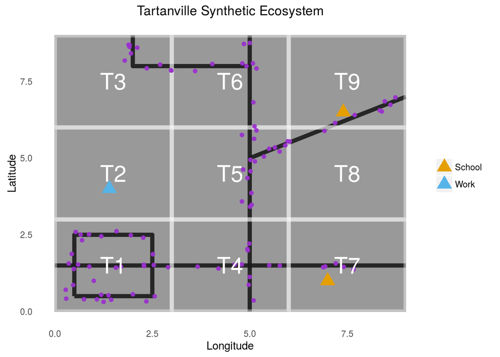

```r
plot_syneco(tartanville, tartanville_syneco,
            region_name = "Tartanville", pretty = TRUE)
```

# Sampling of characteristics

In SPEW, we assign population characteristics to our synthetic agents. We currently support three methods of population characteristics assignment:

1. **Uniform sampling**
2. Moment Matching (MM)
3. Iterative Proportional Fitting (IPF)

## Uniform sampling

Uniform sampling of population characteristics means sampling from the microdata where each record is given equal weight. Thus, if the microdata is thought to be representative of the regions, then the resulting synthetic individuals should have close to the correct distribution of population characteristics. If the microdata is not representative, then we must implement other sampling methods.

**Ex.** As shown in the ‘A true quickstart’ tab.

## Moment Matching

Assume we have the first moment(s) of a continuous or ordered variable(s)’s distribution for every sub-region in the region of interest (e.g. average household size for every block in Tartanville). Moment matching is a method to calculate weights for the microdata records so that after sampling, the sample average of the variable(s) will be matched to the given averages. We demonstrate with the average household size (NP) of Tartanville. The average household sizes have been exaggerated here as we are generating a small synthetic population.

**Ex.**

We first make the `moments` object for use in SPEW. Here, the moments object is the average household size for each block. The function `make_mm_obj` puts the data necessary for MM in the right format. The format is discussed more in another section. The `supplementary_data` is thus a list including the `moments` outputted from `make_mm_obj`.

```r
NP_avg <- c(3.2, 0, 6.0,
            2.0, 3.2, 3.1,
            4.0, 4.8, 3.9)
supplementary_data <- list(moments = make_mm_obj(moments_list =
                           list(mom1 = data.frame(place_id = paste0("T", 1:9),
                                                  puma_id = "T",
                                                  NP = NP_avg)),
                           assumption = "independence",
                                nMom = 1, type = "cont"))
```

And then we use SPEW, with the additional library `quadprog`, which is required for MM. Note we have supplemented `spewr` with both a `supplementary_data` argument and the sampling method of `'mm'`. The outputted synthetic ecosystem is in the same format. We see that MM matches the inputted average household sizes well.

```r
if(!require(quadprog)) install.packages("quadprog")
library(quadprog)
tartanville_syneco_mm <- spewr(tartanville$pop_table, tartanville$shapefile,
                               tartanville$pums_h, tartanville$pums_p,
                               supplementary_data = supplementary_data,
                               sampling_method = "mm")
```

```
## [1] "Region 1 out of 9"
## [1] "Region 2 out of 9"
## [1] "Place has 0 Households!"
## [1] "Region 3 out of 9"
## [1] "Region 4 out of 9"
## [1] "Region 5 out of 9"
## [1] "Region 6 out of 9"
## [1] "Region 7 out of 9"
## [1] "Region 8 out of 9"
## [1] "Region 9 out of 9"
## [1] "Location runs in: 0.58"
```

```r
out <- summarize_syneco(tartanville_syneco_mm,
                 vars_df = data.frame(var_name = c("NP"),
                                      pop_type = c("hh"),
                                      var_type = c("cont"),
                                      stringsAsFactors = FALSE), verbose = TRUE)
```

```
## Variable: NP
##  Summary: place_id Min. 1st Qu. Median  Mean 3rd Qu. Max.
##        T1    2       2      2 3.062       4    6
##        T3    6       6      6 6.000       6    6
##        T4    2       2      2 2.000       2    2
##        T5    2       2      4 3.444       4    6
##        T6    2       2      3 3.400       4    6
##        T7    2       2      4 3.600       4    6
##        T8    4       5      6 5.333       6    6
##        T9    2       3      4 4.286       6    6
```

```r
abs(out$NP$Mean - NP_avg[-2])
```

```
## [1] 0.138 0.000 0.000 0.244 0.300 0.400 0.533 0.386
```

## Iterative Proportional Fitting

Iterative Proportional Fitting is a method discovered by Deming and Stephan (1941) and implemented as a sampling scheme by Beckman et al. (1996). The idea behind IPF is filling in a contingency table where the marginal totals are known. As such, an important step is “cutting” our variables into discrete categories if this has not already been done.

In SPEW, we do this by creating a `marginals` object which contains information both how to cut our variables into categories and how many of each category we expect in each region for each marginal variable. We demonstrate this below.

**Ex.** We must make the `marginals` object for use of the IPF sampling method. We create two marginal objects, one for household income and the other for head of household race and combine them together for use in SPEW.

```r
## Income
var_name <- "HHINC"
## How to cut the variable
type <- "ord"
bounds <- data.frame(lower = c(0, 50), upper = c(49, Inf))
category_name <- c("HHINC_0-49", "HHINC_50-Inf")
## How often we expect to see each category for each region.
df <- data.frame(place_id = paste0("T", 1:9),  v1 = c(30, 0, 5, 10, 13, 9, 2, 1, 5))
df$v2 <- tartanville$pop_table$n_house - df$v1
#
ipf_obj_hhinc<- make_ipf_obj(var_name, type, bounds, category_name, df = df)

ipf_obj_hhinc
```

```
## $HHINC
## $HHINC$df
##   place_id HHINC_0-49 HHINC_50-Inf
## 1       T1         30            2
## 2       T2          0            0
## 3       T3          5            4
## 4       T4         10            2
## 5       T5         13            5
## 6       T6          9            1
## 7       T7          2            3
## 8       T8          1            2
## 9       T9          5            2
##
## $HHINC$type
## [1] "ord"
##
## $HHINC$lookup
##     marg_names lower upper
## 1   HHINC_0-49     0    49
## 2 HHINC_50-Inf    50   Inf
```

```r
## Head of Household Race
var_name <- c("RAC1P")
type <- "cat"
bounds <- data.frame(lower = c(1, 2), upper = c(1, 2))
category_name <- c("Tartan", "Argyle")
df2 <- data.frame(place_id = paste0("T", 1:9),  v1 = c(28, 0, 4, 1, 5, 8, 2, 1, 3))
df2$v2 <- tartanville$pop_table$n_house - df2$v1
#
ipf_obj_rac1p <- make_ipf_obj(var_name, type, bounds, category_name, df = df2)


# Combine both together
ipf_obj <- list(HHINC = ipf_obj_hhinc[[1]], RAC1P = ipf_obj_rac1p[[1]])
supplementary_data <- list(moments = ipf_obj)
```

As demonstration of how we cut our variables, we use a function called `align_pums`.

```r
pums_h <- align_pums(tartanville$pums_h, ipf_obj, suffix = "_ipf") # split into categories
knitr::kable(head(pums_h))
```

| SERIALNO | HHINC | NP | RAC1P | puma_id | HHINC_ipf | RAC1P_ipf |
| --- | --- | --- | --- | --- | --- | --- |
| 1 | 20 | 2 | 1 | T | HHINC_0-49 | Tartan |
| 2 | 42 | 6 | 1 | T | HHINC_0-49 | Tartan |
| 3 | 42 | 4 | 2 | T | HHINC_0-49 | Argyle |
| 4 | 108 | 4 | 1 | T | HHINC_50-Inf | Tartan |
| 5 | 64 | 2 | 1 | T | HHINC_50-Inf | Tartan |

We are now ready to perform IPF-sampling and do so below. We find that IPF matches the table we gave as expected number of households for each category in each marginal variable quite well. **Note:** IPF does not always converge, generally due to having a cell in the contingency with value 0.

```r
if(!require(mipfp)) install.packages("mipfp")
library(mipfp)
tartanville_syneco_ipf <- spewr(tartanville$pop_table, tartanville$shapefile,
                               pums_h, tartanville$pums_p,
                               supplementary_data = supplementary_data,
                               sampling_method = "ipf")
```

```
## [1] "Region 1 out of 9"
## [1] "Region 2 out of 9"
## [1] "Place has 0 Households!"
## [1] "Region 3 out of 9"
```

```
## [1] "Region 4 out of 9"
## [1] "Region 5 out of 9"
```

```
## [1] "Region 6 out of 9"
## [1] "Region 7 out of 9"
## [1] "Region 8 out of 9"
## [1] "Region 9 out of 9"
## [1] "Location runs in: 1.12"
```

```r
out <- summarize_syneco(tartanville_syneco_ipf,
                 vars_df = data.frame(var_name = c("HHINC_ipf", "RAC1P_ipf"),
                                      pop_type = c("hh", "hh"),
                                      var_type = c("cat", "cat"),
                                      stringsAsFactors = FALSE), verbose = TRUE)
```

```
## Variable: HHINC_ipf
##  Summary: place_id HHINC_0-49 HHINC_50-Inf
##        T1         30            2
##        T3          5            4
##        T4         11            1
##        T5         13            5
##        T6          9            1
##        T7          3            2
##        T8          2            1
##        T9          5            2
## Variable: RAC1P_ipf
##  Summary: place_id Tartan Argyle
##        T1     28      4
##        T3      4      5
##        T4      1     11
##        T5      5     13
##        T6      8      2
##        T7      2      3
##        T8      1      2
##        T9      3      4
```

```r
## to compare
sum(abs(as.matrix(out$HHINC_ipf[, -1]) - as.matrix(df[-2, -1])))
```

```
## [1] 6
```

```r
sum(abs(as.matrix(out$RAC1P_ipf[, -1]) - as.matrix(df2[-2, -1])))
```

```
## [1] 0
```

We see we almost match almost perfectly on race and very closely on house hold income.

# Assigning environments

## General assignment function

We can also assign environments to the population of Tartanville. Environments are locations where the agents interact, both with one another, and possibly the environment itself.

**Ex.** We assign the children between ages 5 and 18 in T1 to one of the two schools in Tartanville.

```r
knitr::kable(tartanville$environments)
```

| ID | Type | longitude | latitude | capacity |
| --- | --- | --- | --- | --- |
| Andrew High | School | 7.0 | 1.0 | 10 |
| Maggie Mo High | School | 7.4 | 6.5 | 40 |
| Steel Factory | Work | 1.4 | 4.0 | 100 |

```r
tartanville_syneco <- tartanville_syneco <- spewr(tartanville$pop_table, tartanville$shapefile,
                                                  tartanville$pums_h, tartanville$pums_p)
```

```
## [1] "Region 1 out of 9"
## [1] "Region 2 out of 9"
## [1] "Place has 0 Households!"
## [1] "Region 3 out of 9"
## [1] "Region 4 out of 9"
## [1] "Region 5 out of 9"
## [1] "Region 6 out of 9"
## [1] "Region 7 out of 9"
## [1] "Region 8 out of 9"
## [1] "Region 9 out of 9"
## [1] "Location runs in: 0.57"
```

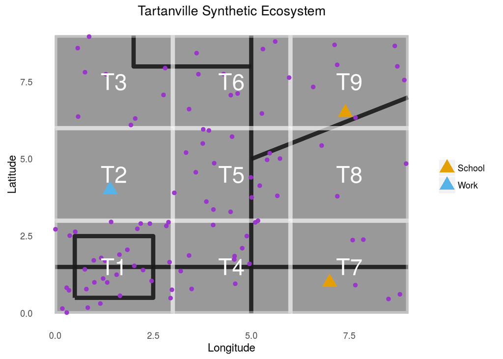

```r
plot_syneco(tartanville, tartanville_syneco,
            region_name = "Tartanville", pretty = TRUE)
```

We first subset the data frame of students in T1.

```r
t1_people <- tartanville_syneco[[1]]$people
t1_students <- subset(t1_people, subset = (t1_people$AGEP >= 5 & t1_people$AGEP <= 18))
places <- subset(tartanville$environments, tartanville$environments$Type == "School")
```

We then assign the schools to the children, first without regard to capacity.

```r
t1_assignments <- assign_place_coords(t1_students, places = places, place_name = "school")
table(t1_assignments$school)
```

```
##
##    Andrew High Maggie Mo High
##             24             18
```

However, we note that Maggie Mo High has about 4 times the capacity than Andrew High. If we take capacity into account, then we have more students going to Maggie Mo High. The user is encouraged to provide their own distance and capacity functions. The details may be found in the documentation of `assign_place_cords`.

```r
t1_assignments <- assign_place_coords(t1_students, places = places, place_name = "school", method = "capacity")
table(t1_assignments$school)
```

```
##
##    Andrew High Maggie Mo High
##              8             34
```

# Essential input data format

SPEW requires three essential data inputs connected through the variables `place_id` and `puma_id`.

[output not shown]

Given a row in the table of population counts with the variables `place_id` and `puma_id`, one should be able to find the unique region `place_id` in the shapefile that matches that of the row along with the microdata records with the same `puma_id`.

Additionally, the above may be combined into a list along with a `roads` variable, `environments` variable and a `supplementary_data` variable to form an object used to spew the final synthetic ecosystem, e.g. the format of `tartanville`

```r
data(tartanville)
names(tartanville)
```

```
## [1] "pop_table"    "shapefile"    "pums_h"       "pums_p"
## [5] "roads"        "environments"
```

```r
class(tartanville)
```

```
## [1] "list"
```

```r
lapply(tartanville, class)
```

```
## $pop_table
## [1] "data.frame"
##
## $shapefile
## [1] "SpatialPolygonsDataFrame"
## attr(,"package")
## [1] "sp"
##
## $pums_h
## [1] "data.frame"
##
## $pums_p
## [1] "data.frame"
##
## $roads
## [1] "SpatialLinesDataFrame"
## attr(,"package")
## [1] "sp"
##
## $environments
## [1] "data.frame"
```

# Supplementary data format

## Supplementary data formats

Due to the increased complexity of the data required for more sophisticated sampling methods, we describe here the form supplementary data required for SPEW to function.

## Road-based sampling (`roads`)

The roads are in the form of spatial lines.

```r
data(tartanville)
class(tartanville$roads)
```

```
## [1] "SpatialLinesDataFrame"
## attr(,"package")
## [1] "sp"
```

To create a synthetic ecosystem, we need to adapt the `shapefile` argument of the function `spewr`. It needs the following format

```
shapefile <- list(boundaries = {orig.shapefile.regions}, roads = {my.roads})
```

## Moment Matching (MM) (`moments`)

The moments object is created through the `make_mm_obj` function. This function requires a `moments_list` argument which has the following format.

- `mom1` a data frame with the columns `place_id`, `puma_id` and `var1` through `var{p}` which are the average for `var1` through `var{p}` respectively for the given place.
- `assumption` is either “independence” or “joint” which effects the sampling.
- `nMom` should be 1 at this moment in time.
- `type` should be “cont” for continuous variables.

  ```
  moments_list <- list(mom1 = data.frame(place_id = {my.place.ids}, puma_id = {my.pumas},
                                     var1 = {var1.avg}, var2 = {var2.avg}, ..., var{p} ={varp.avg}),
                     assumption = {my.assumption},
                     nMom = 1, type = "cont")
  ```

  Finally, the `moments` object is added to the list of supplementary data,

```
supplementary_data <- list(moments = moments)
```

## Iterative Proportional Fitting (IPF) (`marginals`)

The `marginals` requires the most data. The variable `marginals` is itself a list such as

```
list(var1 = ipf_obj_var1[[1]], var2 = ipf_obj_var2[[1]], var{p} = ipf_obj_varp[[1]])
```

The names of the list must be names that are either found in resulting synthetic households or synthetic persons.

The individual IPF objects are created using the `make_ipf_obj` function requiring the following arguments:

- `var_name` name of the variable that must match a column name of the resulting synthetic households or synthetic persons.
- `bounds` either “ord” for ordinal or “cat” for categorical, the type of variable to be converted to
- `category_name` short name of the category, will be visible to person. Either length one and the bounds will be pasted to it or length of the number of rows of the bounds with names of your choice.
- `df` data frame with `place_id` and category counts as columns

Finally, the `marginals` object is added to the list of supplementary data,

```
supplementary_data <- list(marginals = marginals)
```

## Environments (`environments`)

This is a data frame with the following arguments

```
environments <- data.frame(ID = {IDs}, Type = {environment.type},
         longitude = {longitude}, latitude = {latitude},
         capacity = {capacity.of.place})
```

# Advanced SPEW

The tools shown in this vignette are mainly for the generation of small synthetic ecosystems ( < 1 million synthetic individuals). However, SPEW is equipped to produce large synthetic ecosystems.

The function `call_spew` is a function that automates the process of reading in data from pre-specified folders and writes out the synthetic ecosystems to files within an output folder.

It is helpful to have the following directory structure

- region_to_spew
  - input
    - counts
    - marginals
    - pums
    - shapefiles
  - output
  - logfiles

In `call_spew`, two formats have been adapted to speed the process of SPEW due to the similar nature of the data. The first is “usa” for US states as the data all originates from the US Census. The second is “ipums” where the data originates from [IPUMS-I](https://international.ipums.org/international/) and [GeoHive](http://geohive.com/).

A third custom option is available for data sources that do not fit into either of the above options.

Additionally, `call_spew` has been adapted to specifically assign schools from [NCES](http://nces.ed.gov/ipeds/datacenter/) so that children are assigned to either private or public schools, within the county if possible based upon the appropriate grade range from the microdata from the US Census.

Functions are available to provide graphical and textual summaries of these synthetic ecosystems generated by `call_spew`.

Finally, `call_spew` has been painstakingly designed to support 3 parallel back ends (SOCK, RMPI, and MC) to provide the most efficient use of available computing resources in addition to the non-parallel “SEQ” option.

For more information, please see the [full documentation](https://github.com/leerichardson/spew/blob/master/olympus/documentation/spew_documentation.pdf).